# Using DEP for Volcano Plots

```r
library("DEP")
library("dplyr")
library(readr)
library(tidyverse)
library(glue)
```

## Your Files

Make sure both your `combined_proteins` and `experiment_annotations` files are placed in the `data` folder. Once that’s done, you can just paste in the **file names** into the two variables below:

```r
combined_proteins_file="combined_protein_astrocytes_sex_time.tsv"
experiment_annotation_file="experiment_annotation_astrocytes_sex_time.tsv"
```

## Reading data in

```r
proteins_raw <- read_tsv(file = paste0("../data/", combined_proteins_file)) |> as.data.frame()
metadata_raw <- read_tsv(file = paste0("../data/", experiment_annotation_file)) |> as.data.frame()
```

## Data Formatting

```r
# Remove spaces from column names
# "make.names" is a special function that formats all column names
proteins_raw_renamed <- proteins_raw |> rename_with(make.names)

# Remove Contamination
proteins_raw_remove_contam <- proteins_raw_renamed |> filter(!grepl("contam", Protein))

# Select the important columns
proteins <- select(proteins_raw_remove_contam, Protein, Protein.ID, Entry.Name, Description, contains("MaxLFQ"))
```

## Changing Column Names to work with DEP

Naturally, DEP expects the `combined_proteins.tsv` and `experiment_annotations.tsv` to be in the format of MaxQuant outputs. The main difference in data format is that MaxQuant has `"LFQ.intensity.CONDITION"`, while Fragpipe outputs `"CONDITION.MaxLFQ.Intensity"`.

The following code changes all column names to match what `DEP` expects.

#### Add on “LFQ.intensity” before the data columns

```r
# Select only the columns that contain "MaxLFQ" and
#   add on "LFQ.intensity" using paste0
colnames(proteins)[grep("MaxLFQ", colnames(proteins))] <- paste0("LFQ.intensity.", colnames(proteins)[grep("MaxLFQ", colnames(proteins))])

colnames(proteins)
```

```
##  [1] "Protein"
##  [2] "Protein.ID"
##  [3] "Entry.Name"
##  [4] "Description"
##  [5] "LFQ.intensity.female_33_1_1.MaxLFQ.Intensity"
##  [6] "LFQ.intensity.female_33_2_2.MaxLFQ.Intensity"
##  [7] "LFQ.intensity.female_33_3_3.MaxLFQ.Intensity"
##  [8] "LFQ.intensity.female_37_1_1.MaxLFQ.Intensity"
##  [9] "LFQ.intensity.female_37_2_2.MaxLFQ.Intensity"
## [10] "LFQ.intensity.female_37_3_3.MaxLFQ.Intensity"
## [11] "LFQ.intensity.male_33_1_1.MaxLFQ.Intensity"
## [12] "LFQ.intensity.male_33_2_2.MaxLFQ.Intensity"
## [13] "LFQ.intensity.male_33_3_3.MaxLFQ.Intensity"
## [14] "LFQ.intensity.male_37_1_1.MaxLFQ.Intensity"
## [15] "LFQ.intensity.male_37_2_2.MaxLFQ.Intensity"
## [16] "LFQ.intensity.male_37_3_3.MaxLFQ.Intensity"
```

### Remove the `.MaxLFQ.Intensity` from the end

```r
# Replace it with "" (nothing)
colnames(proteins) <- gsub(pattern =".MaxLFQ.Intensity",
                                       replace="",
                                       colnames(proteins),
                                       fixed = TRUE)

colnames(proteins)
```

```
##  [1] "Protein"                     "Protein.ID"
##  [3] "Entry.Name"                  "Description"
##  [5] "LFQ.intensity.female_33_1_1" "LFQ.intensity.female_33_2_2"
##  [7] "LFQ.intensity.female_33_3_3" "LFQ.intensity.female_37_1_1"
##  [9] "LFQ.intensity.female_37_2_2" "LFQ.intensity.female_37_3_3"
## [11] "LFQ.intensity.male_33_1_1"   "LFQ.intensity.male_33_2_2"
## [13] "LFQ.intensity.male_33_3_3"   "LFQ.intensity.male_37_1_1"
## [15] "LFQ.intensity.male_37_2_2"   "LFQ.intensity.male_37_3_3"
```

## Extract protein name from `Entry.Name`

```r
## Split the Protein name by delimiter "|"
proteins <- separate_wider_delim(proteins, cols=Protein, delim = "|", names = c("first", "second", "third"))

# Split again to remove the "HUMAN" part of "XXX_HUMAN"
proteins <- separate_wider_delim(proteins, cols = third, delim = "_", names= c("name", "human"))

# Remove other columns that we made during the process
proteins <- proteins %>% select(-c("first", "second", "human"))
```

```r
# Use DEP's function to prepare final version
proteins_for_dep <- make_unique(proteins,
                                  names="name",
                                  ids="Protein.ID")
```

## Make SummarizedExperiment Object

### Prepare LFQ Column Numbers for DEP

```r
# DEP needs the column numbers that actually have the LFQ intensities
LFQ_columns <- grep("LFQ", colnames(proteins_for_dep))
```

### Prepare Metadata for DEP

```r
# Remove columns we don't need
metadata_for_dep = metadata_raw |> select(-c(file, sample))

# Rename columns, since DEP is expecting only three columns:
#  "label", "condition", "replicate"
metadata_for_dep = metadata_for_dep |> rename("label" = "sample_name")
```

### Make the SummarizedExperiment Object

```r
# Use DEP to make a SummarizedExperiment (se) object
data <- make_se(proteins_for_dep, LFQ_columns, metadata_for_dep)
```

## Visualizations of Data

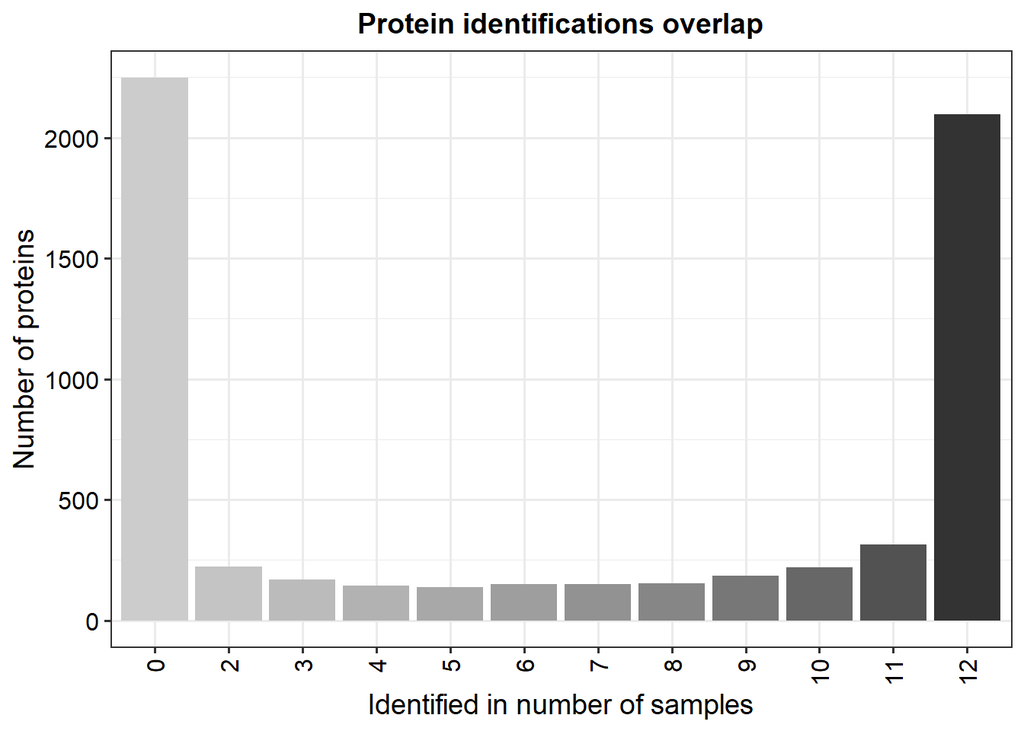

```r
plot_frequency(data)
```

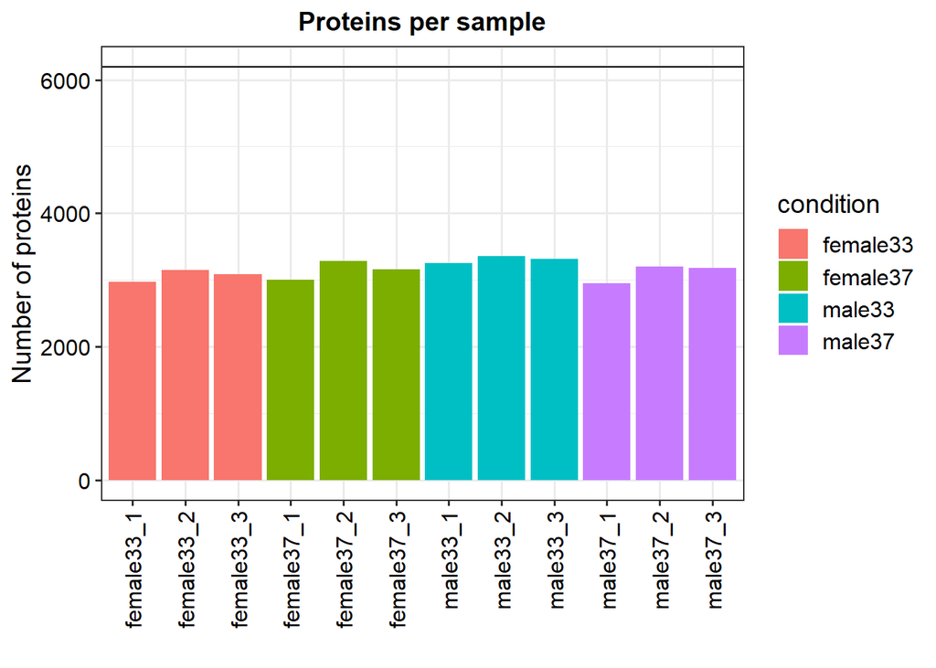

```r
plot_numbers(data)
```

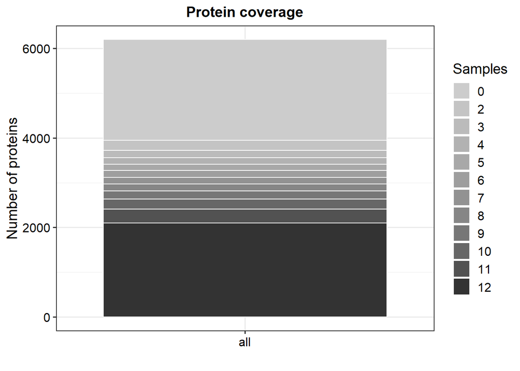

```r
plot_coverage(data)
```

```r
data_normalized <- normalize_vsn(data)
```

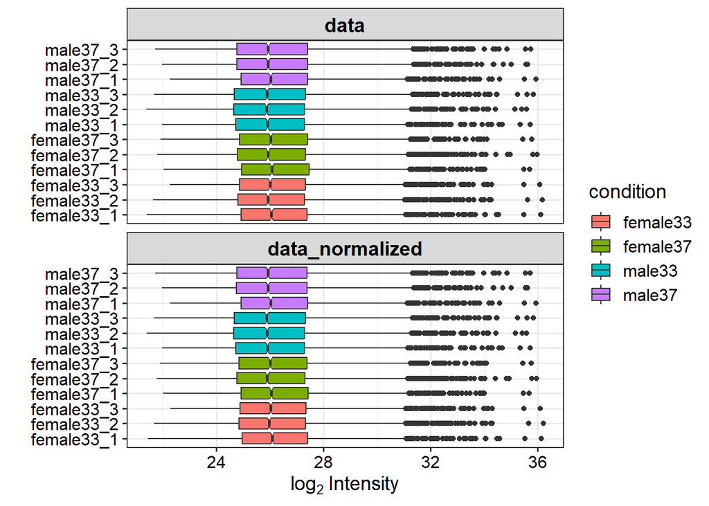

```r
plot_normalization(data, data_normalized)
```

```
## `use_raster` is automatically set to TRUE for a matrix with more than
## 2000 rows. You can control `use_raster` argument by explicitly setting
## TRUE/FALSE to it.
##
## Set `ht_opt$message = FALSE` to turn off this message.
```

```
## 'magick' package is suggested to install to give better rasterization.
##
## Set `ht_opt$message = FALSE` to turn off this message.
```

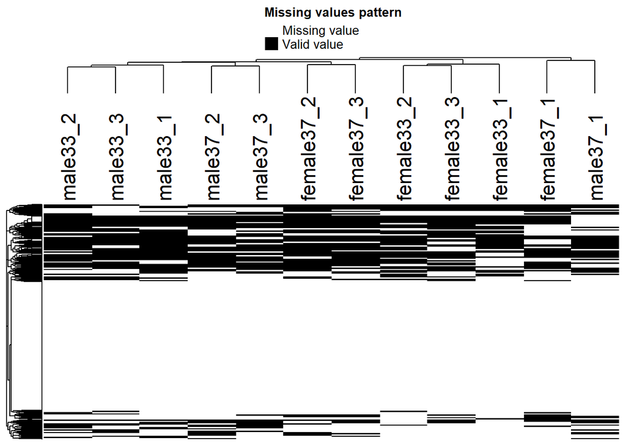

```r
plot_missval(data)
```

```r
data_imputed <- impute(data_normalized, fun = "MinProb", q = 0.01)
```

```
## [1] 0.2459178
```

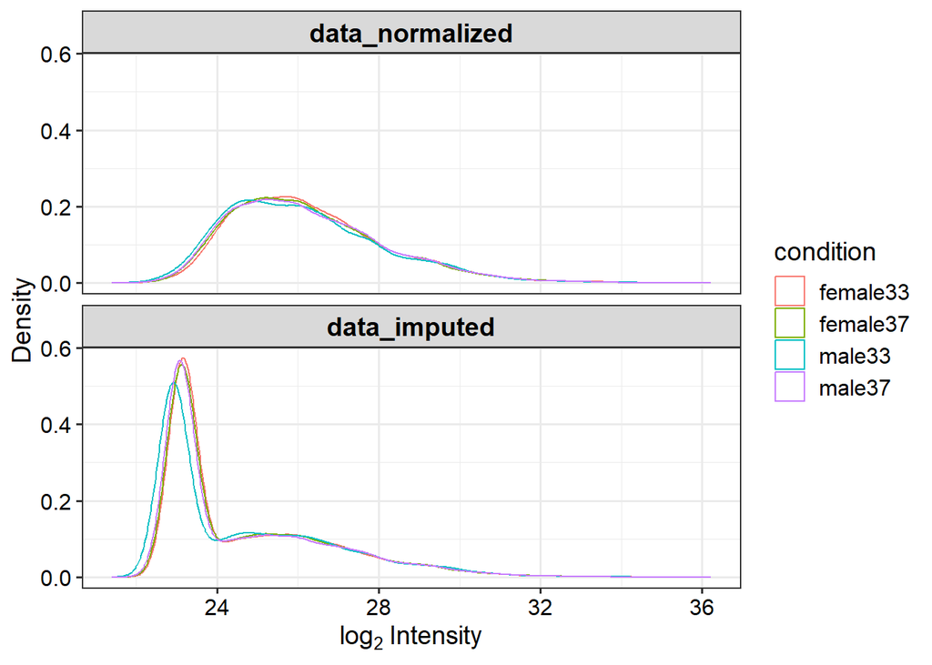

```r
plot_imputation(data_normalized, data_imputed)
```

## Differential Enrichment Analysis

Contrasts need to be defined in the format of `CONDITION1_vs_CONDITION2` , and they need to match the name in the `condition` column in `metadata_for_dep`. For example, if you want to compare the condition `"control123"` with `"wildtype456"`, then the manual contrast will be `"control123_vs_wildtype456"`.

```r
# Manually define contrasts for the volcano plot
data_contrasts <- test_diff(data_imputed, type = "manual",
                              test = c("female37_vs_male37",
                                       "female33_vs_male33"))
```

```
## Tested contrasts: female37_vs_male37, female33_vs_male33
```

## Make DEP object

`alpha`: The threshold for the adjusted p-value. Here, a sample value of `0.05` is used.

`lfc`: the threshold for the log2 fold change. Here, a sample value of `1.5` fold change (then logged)

```r
dep <- add_rejections(data_contrasts, alpha = 0.05, lfc = log2(1.5))
```

## Visualizations for DEP objects

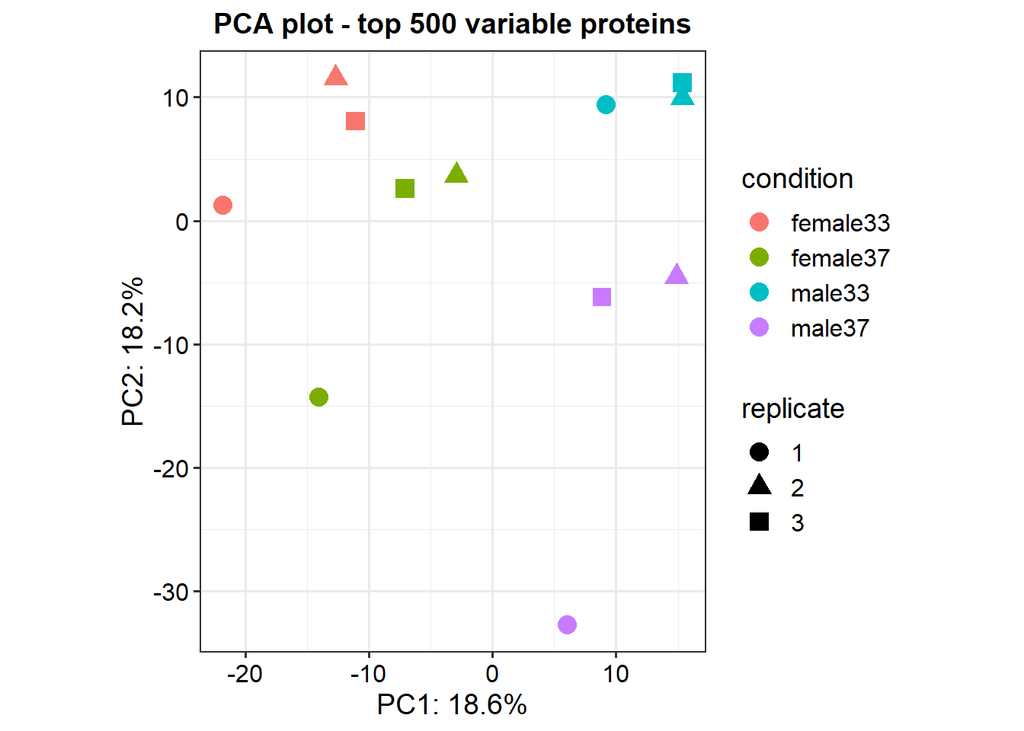

```r
plot_pca(dep, x = 1, y = 2, n = 500, point_size = 4)
```

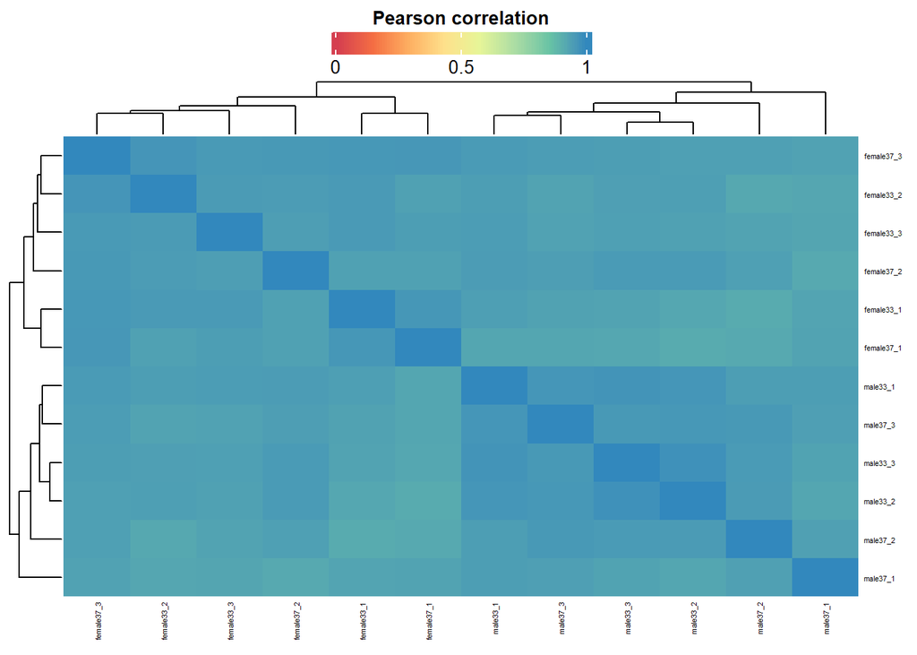

```r
plot_cor(dep, significant = TRUE, lower = 0, upper = 1, pal = "Spectral", font_size = 4)
```

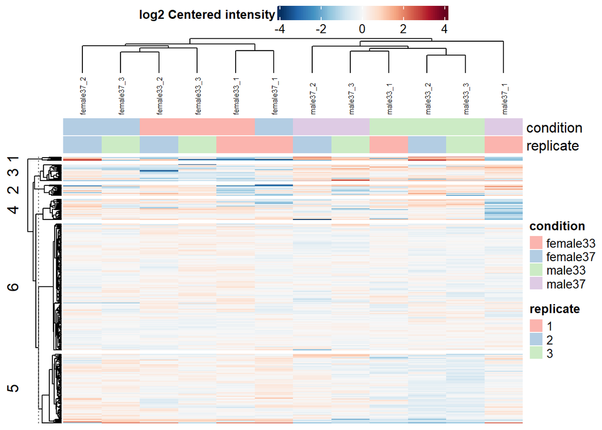

```r
plot_heatmap(dep, type = "centered", kmeans = TRUE,  col_limit = 4,
             show_row_names = FALSE, indicate = c("condition", "replicate"),
             col_font_size = 6)
```

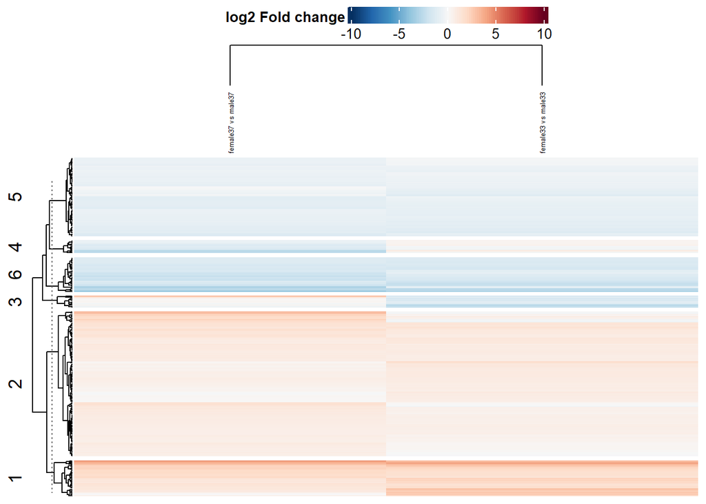

```r
plot_heatmap(dep, type = "contrast", kmeans = TRUE, col_font_size = 5,
             k = 6, col_limit = 10, show_row_names = FALSE)
```

### Volcano Plots for Contrasts

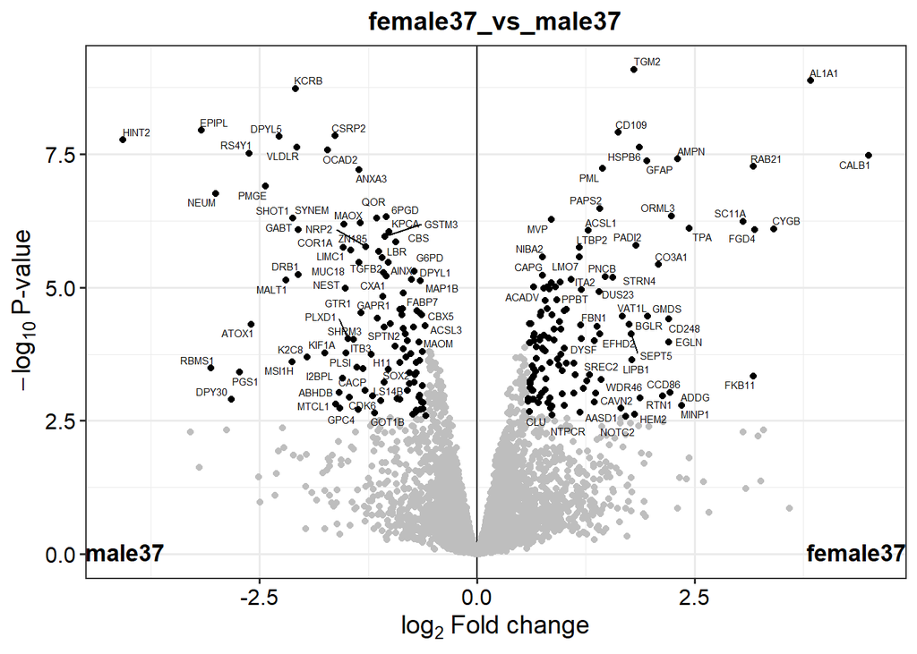

```r
plot_volcano(dep, contrast = "female37_vs_male37", label_size = 2, add_names = TRUE)
```

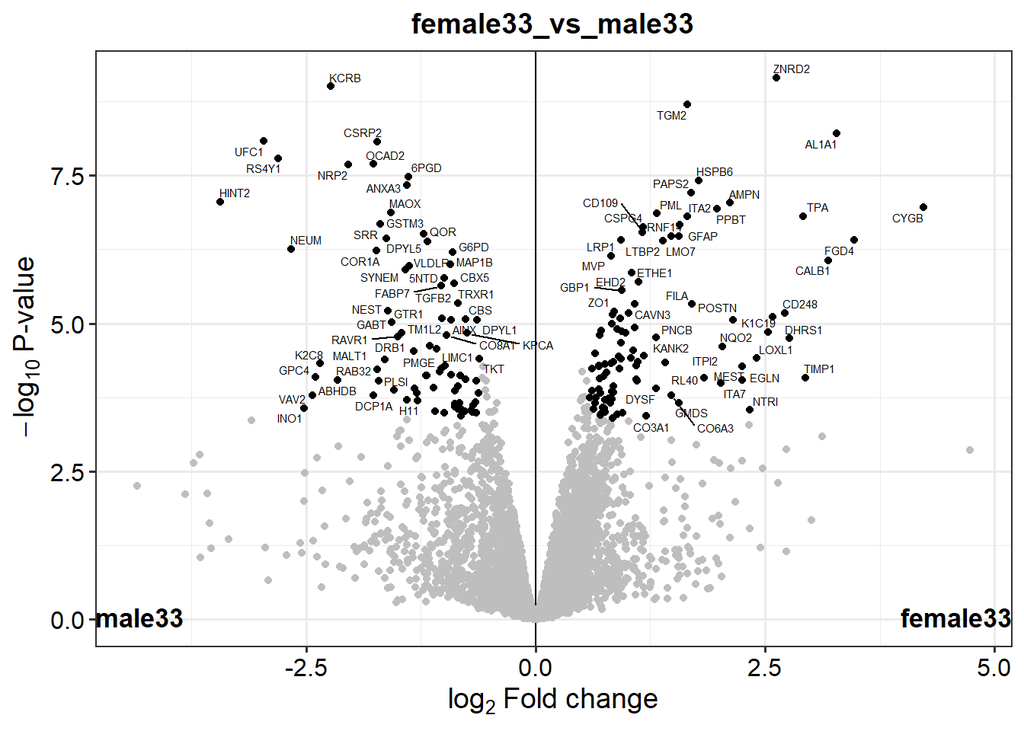

```r
plot_volcano(dep, contrast = "female33_vs_male33", label_size = 2, add_names = TRUE)
```